# EDA Notebook for Swire Coca-Cola Delivery Standardization Project

Jessica Kersey

2025-02-22

# Introduction

**Project Goal:** Identify characteristics of customers that order above a specific threshold annually to determine what might indicate “high growth potential” in customers below the threshold.

**Business Problem Summary:** Swire Coca-Cola wants to optimize logistic transport costs by changing some direct delivery (“red truck”) customers to a third-party delivery (“white truck”). They need to identify characteristics of customers which order greater than 400 gallons of product per year in order to determine which customers below this threshold might have “high growth potential”. These “high growth potential” customers may exceed the 400 gallon threshold in the future if they continue with red truck delivery and business support services instead of being swapped to white truck.

**Analytics Problem Summary:** Using historical sales data and customer characteristics, identify characteristics of customers which have high growth across the given 2023-2024 data.

**Notebook Purpose:** This notebook includes unsupervised clustering models to investigate if there are natural groups of customers with similar characteristics, including growth rate.

# Get Data

Load library packages.

```r
#load library packages
library(tidyverse) # for advanced stats including dplyr and ggplot
library(skimr) # for advanced stats
library(readxl) # for reading in xlsx file
library(robustbase) # for outlier detection
library(chemometrics) # for outlier detection
library(car) # for VIF
library(parallel) # for parallel processing
library(foreach) # for parallel processing
library(rpart) #for classification tree model
library(rpart.plot) #for plotting classification tree model
library(gt) #for table formatting
library(caret) # for dummy variables
library(cluster) # for partition clustering
library(factoextra) # for cluster plots
library(kernlab) # for kernel clustering
library(tictoc) # for timing
```

Load data cleaned by a teammate.

```r
# load group's final datasets
complete_data <- read.csv("complete_data.csv")

complete_data_subset <- read.csv("complete_data_subset.csv")
```

# Clustering Modeling

## Preparing for Clustering

### Recode & Scale Whole Dataset

Recode categorical variables into dummy variables or remove them, then scale all columns.

```r
# Remove columns captured by engineered fields
complete_trimmed <- complete_data %>%
  select(-c(CUSTOMER_NUMBER,           # ID column
            TRADE_CHANNEL.y,           # duplicate
            null                       # unclear column
         )) %>%
  mutate(percent_change = ifelse(is.na(percent_change),        # convert NAs to...
                                 0,                            # 0
                                 percent_change),              # otherwise leave the same
         percent_change = ifelse(is.infinite(percent_change),  # convert Infs to...
                                 0,                            # 0
                                 percent_change)               # otherwise leave the same
         )

# Extract identifier column
CUSTOMER_NUMBER_col <- complete_data$CUSTOMER_NUMBER

# Extract non-categorical cols
complete_num <- complete_trimmed %>%
  select(-c(growth_category, TRADE_CHANNEL.x, CO2_CUSTOMER, COLD_DRINK_CHANNEL,
            SUB_TRADE_CHANNEL, LOCAL_MARKET_PARTNER, FREQUENT_ORDER_TYPE,
            fountain_only))

# Recode categorical into dummy variables
complete_recoded <- complete_trimmed %>%
  # create dummy variables model
  dummyVars(data = ., formula = ~ growth_category + TRADE_CHANNEL.x
            + CO2_CUSTOMER + COLD_DRINK_CHANNEL + SUB_TRADE_CHANNEL
            + LOCAL_MARKET_PARTNER + FREQUENT_ORDER_TYPE + fountain_only
            ) %>%
  # apply dummy variables model
  predict(object = .,
          newdata = complete_trimmed)

# combine and scale all columns
complete_dummy_scaled <- cbind(complete_num, complete_recoded) %>%
  scale(x = .,
        scale = TRUE,
        center = TRUE) %>%
  as.data.frame()
```

### Recode & Scale Subset Dataset

Do the same for the subset of customers.

```r
# Remove columns captured by engineered fields
subset_trimmed <- complete_data_subset %>%
  select(-c(CUSTOMER_NUMBER,           # ID column
            TRADE_CHANNEL.y,           # duplicate
            cases_total, EDI           # no variation
         )) %>%
  mutate(percent_change = ifelse(is.na(percent_change),        # convert NAs to...
                                 0,                            # 0
                                 percent_change),              # otherwise leave the same
         percent_change = ifelse(is.infinite(percent_change),  # convert Infs to...
                                 0,                            # 0
                                 percent_change)               # otherwise leave the same
         )

# Extract identifier column
CUSTOMER_NUMBER_col_subset <- complete_data_subset$CUSTOMER_NUMBER

# Extract non-categorical cols
subset_num <- subset_trimmed %>%
  select(-c(growth_category, TRADE_CHANNEL.x, COLD_DRINK_CHANNEL,
            SUB_TRADE_CHANNEL, FREQUENT_ORDER_TYPE))

# Recode categorical into dummy variables
subset_recoded <- subset_trimmed %>%
  # create dummy variables model
  dummyVars(data = ., formula = ~ growth_category + TRADE_CHANNEL.x
            + COLD_DRINK_CHANNEL + SUB_TRADE_CHANNEL + FREQUENT_ORDER_TYPE
            ) %>%
  # apply dummy variables model
  predict(object = .,
          newdata = subset_trimmed)

# combine and scale all columns
subset_dummy_scaled <- cbind(subset_num, subset_recoded) %>%
  scale(x = .,
        scale = TRUE,
        center = TRUE) %>%
  as.data.frame()
```

## K-means Clustering

Try kmeans partition clustering on full dataset with dummy variables, using Euclidean distance.

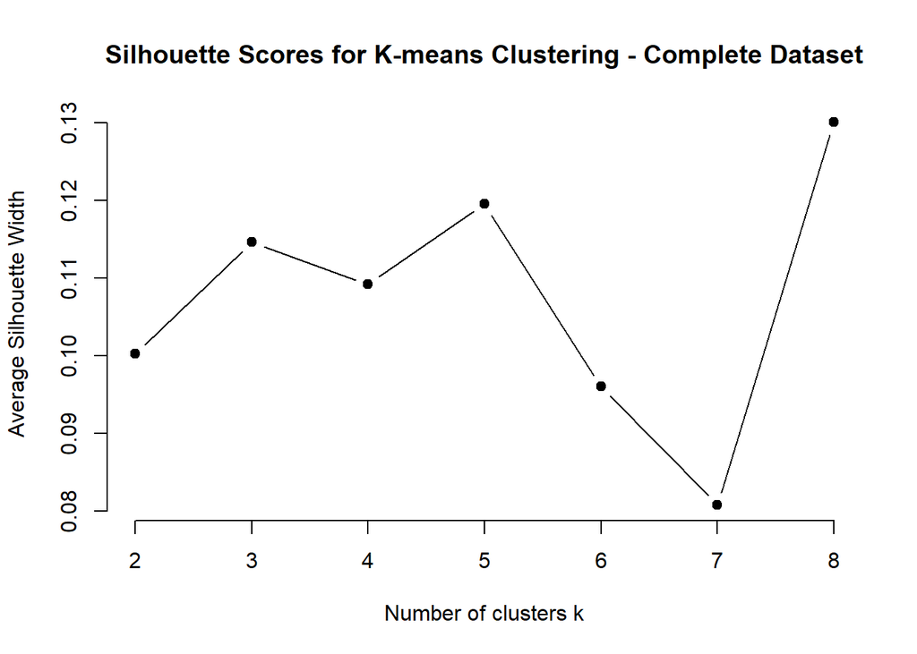

```r
tic()

# specify parallel processing
doParallel::registerDoParallel(cores = 24)

# define function to calculate silhouette widths
silhouette_widths_kmean_c <- function(k) {
  # set seed within function so it applies to parallel sessions
  set.seed(25463)
  kmeans <- kmeans(complete_dummy_scaled, centers = k, nstart = 20, iter.max = 100) # kmeans with k centers
  dist <- dist(complete_dummy_scaled, method = "euclidean")
  sil <- silhouette(kmeans$cluster, dist)
  mean(sil[ ,3]) # calculate silhouette for each and take mean
}

# Calculate average silhouette width for different numbers of clusters
avg_silwidth_kmean_c <- foreach(k = 2:8,     # 8 = Max reasonable # of customer groups
                                .combine = c,  # c = combine results into vector
                                .packages = 'cluster'  # ensure parallel sessions have cluster package
                                ) %dopar% {   # foreach with %dopar% utilizes parallel processing
  silhouette_widths_kmean_c(k)
  }

# Plot the Silhouette Method
plot(2:8, avg_silwidth_kmean_c, type = "b", pch = 19, frame = FALSE,
     xlab = "Number of clusters k",
     ylab = "Average Silhouette Width",
     main = "Silhouette Scores for K-means Clustering - Complete Dataset")
```

```r
# stop parallel processing
doParallel::stopImplicitCluster()

toc()
```

```
## 42.36 sec elapsed
```

The best value looks around 0.13, well below the ideal silhouette score of 0.5 or more. It is increasing, however, this model is likely not accurately describing variation in the dataset.

Try kmeans partition clustering on the subset with dummy variables, using Euclidean distance.

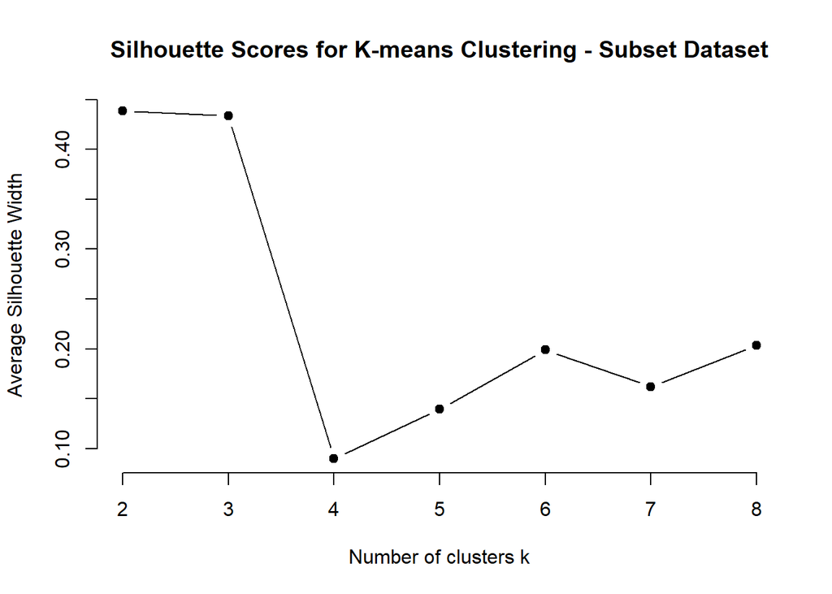

```r
tic()

# specify parallel processing
doParallel::registerDoParallel(cores = 24)

# define function to calculate silhouette widths
silhouette_widths_kmean_s <- function(k) {
  # set seed within function so it applies to parallel sessions
  set.seed(25463)
  kmeans <- kmeans(subset_dummy_scaled, centers = k, nstart = 20, iter.max = 100) # kmeans with k centers
  dist <- dist(subset_dummy_scaled, method = "euclidean")
  sil <- silhouette(kmeans$cluster, dist)
  mean(sil[ ,3]) # calculate silhouette for each and take mean
}

# Calculate average silhouette width for different numbers of clusters
avg_silwidth_kmean_s <- foreach(k = 2:8,     # 8 = Max reasonable # of customer groups
                                .combine = c,  # c = combine results into vector
                                .packages = 'cluster'  # ensure parallel sessions have cluster package
                                ) %dopar% {   # foreach with %dopar% utilizes parallel processing
  silhouette_widths_kmean_s(k)
  }

# Plot the Silhouette Method
plot(2:8, avg_silwidth_kmean_s, type = "b", pch = 19, frame = FALSE,
     xlab = "Number of clusters k",
     ylab = "Average Silhouette Width",
     main = "Silhouette Scores for K-means Clustering - Subset Dataset")
```

```r
# stop parallel processing
doParallel::stopImplicitCluster()

toc()
```

```
## 0.48 sec elapsed
```

The best score is below 0.45 for 2 clusters, barely below the ideal threshold of 0.5.

## Kernel K-means Clustering

Try kernel k-means partition clustering on full dataset with dummy variables, in case data is non-linearly separable.

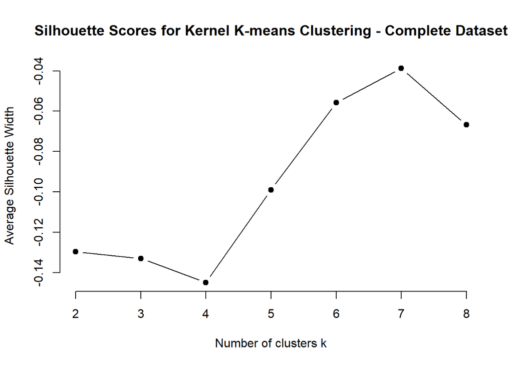

```r
tic()

# specify parallel processing
doParallel::registerDoParallel(cores = 24)

# define function to calculate silhouette widths
silhouette_widths_kkmean_c <- function(k) {
  # set seed within function so it applies to parallel sessions
  set.seed(25463)
  # kkmeans with k clusters, using radial basis function
  kkmeans <- kkmeans(as.matrix(complete_dummy_scaled), centers = k, kernel = "rbfdot",
                     kpar = list(sigma = 0.1))
  dist <- dist(complete_dummy_scaled, method = "euclidean")
  sil <- silhouette(kkmeans@.Data, dist)
  mean(sil[ ,3]) # calculate silhouette for each and take mean
}

# Calculate average silhouette width for different numbers of clusters
avg_silwidth_kkmean_c <- foreach(k = 2:8,     # 8 = Max reasonable # of customer groups
                                .combine = c,  # c = combine results into vector
                                .packages = c('cluster',  # ensure parallel sessions have cluster package
                                              'kernlab') # same for kernlab
                                ) %dopar% {   # foreach with %dopar% utilizes parallel processing
  silhouette_widths_kkmean_c(k)
  }

# Plot the Silhouette Method
plot(2:8, avg_silwidth_kkmean_c, type = "b", pch = 19, frame = FALSE,
     xlab = "Number of clusters k",
     ylab = "Average Silhouette Width",
     main = "Silhouette Scores for Kernel K-means Clustering - Complete Dataset")
```

```r
# stop parallel processing
doParallel::stopImplicitCluster()

toc()
```

```
## 1024.87 sec elapsed
```

Kernel k-means clustering using the Radial Basis kernel is worse, with -0.04 as the best silhouette width. This indicates extremely poor clustering, likely worse than random assignment!

Try kernel k-means partition clustering on subset dataset with dummy variables, in case data is non-linearly separable.

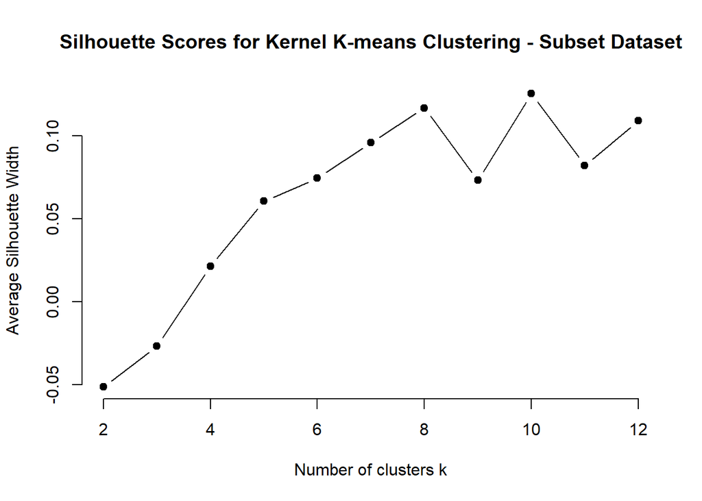

```r
tic()

# specify parallel processing
doParallel::registerDoParallel(cores = 24)

# define function to calculate silhouette widths
silhouette_widths_kkmean_s <- function(k) {
  # set seed within function so it applies to parallel sessions
  set.seed(25463)
  # kkmeans with k clusters, using radial basis function
  kkmeans <- kkmeans(as.matrix(subset_dummy_scaled), centers = k, kernel = "rbfdot",
                     kpar = list(sigma = 0.1))
  dist <- dist(subset_dummy_scaled, method = "euclidean")
  sil <- silhouette(kkmeans@.Data, dist)
  mean(sil[ ,3]) # calculate silhouette for each and take mean
}

# Calculate average silhouette width for different numbers of clusters
avg_silwidth_kkmean_s <- foreach(k = 2:12,     # 12 = Max reasonable # of customer groups
                                .combine = c,  # c = combine results into vector
                                .packages = c('cluster',  # ensure parallel sessions have cluster package
                                              'kernlab') # same for kernlab
                                ) %dopar% {   # foreach with %dopar% utilizes parallel processing
  silhouette_widths_kkmean_s(k)
  }

# Plot the Silhouette Method
plot(2:12, avg_silwidth_kkmean_s, type = "b", pch = 19, frame = FALSE,
     xlab = "Number of clusters k",
     ylab = "Average Silhouette Width",
     main = "Silhouette Scores for Kernel K-means Clustering - Subset Dataset")
```

```r
# stop parallel processing
doParallel::stopImplicitCluster()

toc()
```

```
## 1.75 sec elapsed
```

## K-Medoid Clustering

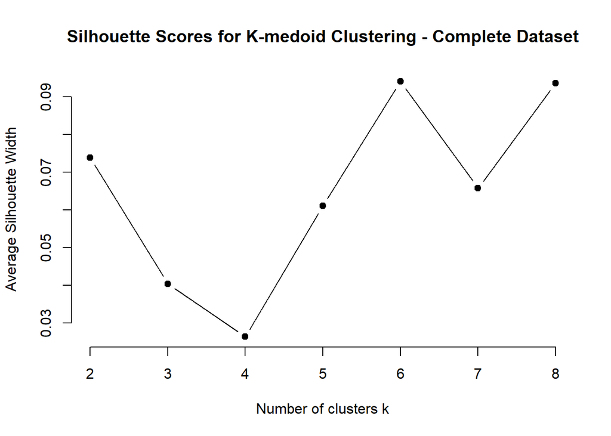

```r
tic()

# specify parallel processing
doParallel::registerDoParallel(cores = 24)

# define function to calculate silhouette widths
silhouette_widths_kmed_c <- function(k) {
  # set seed within function so it applies to parallel sessions
  set.seed(25463)
  kmedoid <- pam(complete_dummy_scaled, k) # k-medoid with k centers
  kmedoid$silinfo$avg.width
}

# Calculate average silhouette width for different numbers of clusters
avg_silwidth_kmed_c <- foreach(k = 2:8,     # 8 = Max reasonable # of customer groups
                                .combine = c,  # c = combine results into vector
                                .packages = 'cluster'  # ensure parallel sessions have cluster package
                                ) %dopar% {   # foreach with %dopar% utilizes parallel processing
  silhouette_widths_kmed_c(k)
  }

# Plot the Silhouette Method
plot(2:8, avg_silwidth_kmed_c, type = "b", pch = 19, frame = FALSE,
     xlab = "Number of clusters k",
     ylab = "Average Silhouette Width",
     main = "Silhouette Scores for K-medoid Clustering - Complete Dataset")
```

```r
# stop parallel processing
doParallel::stopImplicitCluster()

toc()
```

```
## 145.28 sec elapsed
```

This model is about 0.10 silhoutte score, again, not capturing variation well.

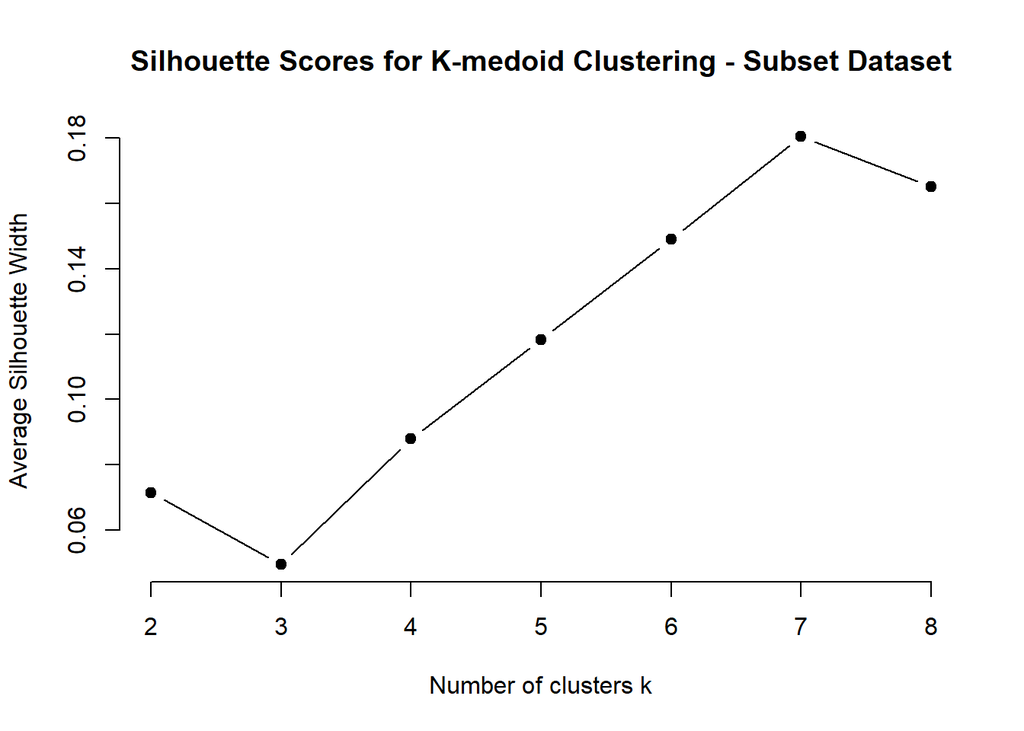

```r
tic()

# specify parallel processing
doParallel::registerDoParallel(cores = 24)

# define function to calculate silhouette widths
silhouette_widths_kmed_s <- function(k) {
  # set seed within function so it applies to parallel sessions
  set.seed(25463)
  kmedoid <- pam(subset_dummy_scaled, k) # k-medoid with k centers
  kmedoid$silinfo$avg.width
}

# Calculate average silhouette width for different numbers of clusters
avg_silwidth_kmed_s <- foreach(k = 2:8,     # 8 = Max reasonable # of customer groups
                                .combine = c,  # c = combine results into vector
                                .packages = 'cluster'  # ensure parallel sessions have cluster package
                                ) %dopar% {   # foreach with %dopar% utilizes parallel processing
  silhouette_widths_kmed_s(k)
  }

# Plot the Silhouette Method
plot(2:8, avg_silwidth_kmed_s, type = "b", pch = 19, frame = FALSE,
     xlab = "Number of clusters k",
     ylab = "Average Silhouette Width",
     main = "Silhouette Scores for K-medoid Clustering - Subset Dataset")
```

```r
# stop parallel processing
doParallel::stopImplicitCluster()

toc()
```

```
## 0.52 sec elapsed
```

The elbow is at 0.18 silhouette score for 7 clusters, which is again not capturing variation in the dataset well.

# Results - Best Partition Cluster

Visualize the best partition cluster identified above (K-means clustering on the subset customers).

```r
# max silhouette score
cat(paste("Maximum Silhouette Score:\n"), max(avg_silwidth_kmean_s))
```

```
## Maximum Silhouette Score:
##  0.4382941
```

```r
# index for silhouette score (cluster qty starts at 2, index starts at 1)
cat(paste("\nIndex:\n"),(which.max(avg_silwidth_kmean_s) + 1))
```

```
##
## Index:
##  2
```

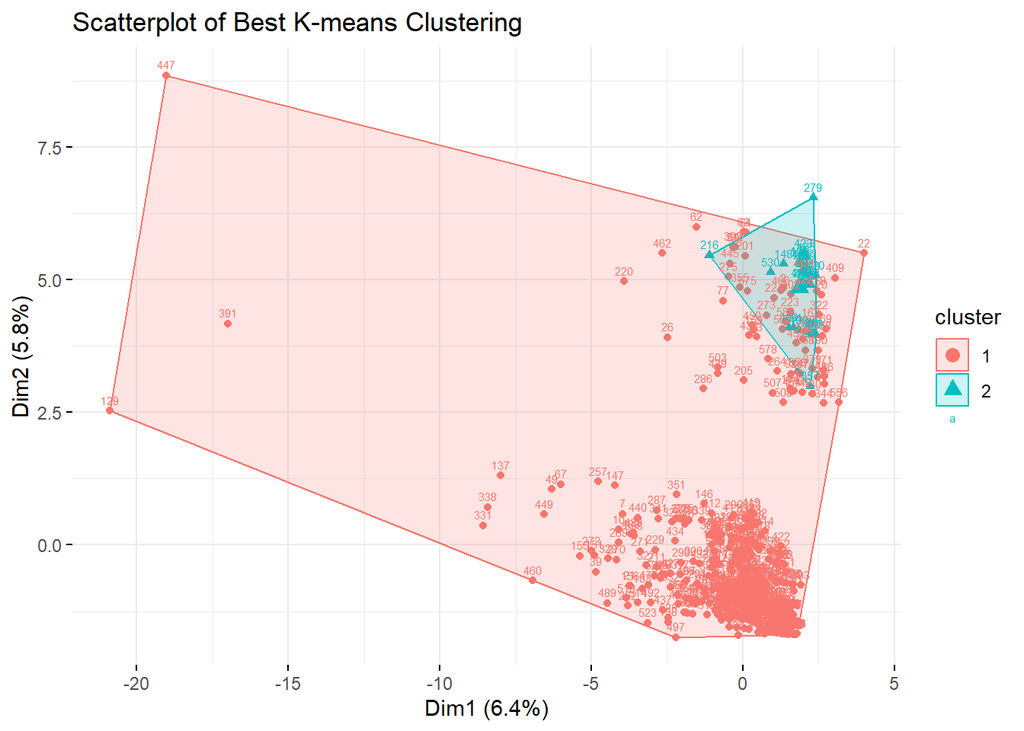

```r
# best partition cluster
best_pc <- kmeans(subset_dummy_scaled, centers = 2, nstart = 20, iter.max = 100)

# plot best partition cluster
fviz_cluster(object = best_pc,
             data = subset_dummy_scaled,
             main = "Scatterplot of Best K-means Clustering",
             labelsize = 6,
             ggtheme = theme_minimal())
```